# STATS506 Problem Set #02

Author

Fan Zhang

Published

September 24, 2023

GitHub Repository: https://github.com/cajole-fff/UMich-STATS506-FanZhang/

## Problem 1 - Dice Game

Let’s play a dice game. It costs $2 to play. You roll a single 6-sided die. * On a roll of 2, 4, or 6, you win the amount on the roll (e.g. a roll of 4 wins $4). * On a roll of 1, 3, or 5, you lose. We’re going to implement this in different ways. Each function takes in as input the number of dice to roll, and each function returns your total winnings or loses.

**a. Implement various versions of this game.**

Version 1. Implement this game using a loop over the die rolls.

```r
play_dice_lp <- function(num_die_rolls = 1){
    winnings <- 0
    for(i in 1:num_die_rolls){
        roll <- sample(1:6, 1)
        winnings <- winnings + (1 - (roll %% 2)) * roll - 2
    }
    return(winnings)
}
```

Version 2. Implement this game using built-in R vectorized functions.

```r
play_dice_vt <- function(num_die_rolls = 1){
    rolls <- sample(1:6, num_die_rolls, replace = TRUE)
    winnings <- sum((1 - (rolls %% 2)) * rolls) - 2 * num_die_rolls
    return(winnings)
}
```

Version 3. Implement this by collapsing the die rolls into a single `table()`. (Hint: Be careful indexing the table - what happens if you make a table of 5 dice rolls? You may need to look to other resources for how to solve this.)

```r
play_dice_tb <- function(num_die_rolls = 1){
    rolls <- sample(1:6, num_die_rolls, replace = TRUE)
    rolls <- table(rolls)
    winnings <- sum(as.numeric(names(rolls)) * (1 - (as.numeric(names(rolls)) %% 2)) * rolls) - 2 * num_die_rolls
    return(winnings)
}
```

Version 4. Implement this game by using one of the “apply” functions.

```r
single_roll_amount <- function(roll) {
    return ((1 - (roll %% 2)) * roll)
}

play_dice_ap <- function(num_die_rolls = 1){
    rolls <- sample(1:6, num_die_rolls, replace = TRUE)
    winnings <- sum(sapply(rolls, single_roll_amount)) - 2 * num_die_rolls
    return(winnings)
}
```

**b. Demonstrate that all versions work. Do so by running each a few times, once with an input a 3, and once with an input of 3000.**

```r
cat("play_dice_lp(3):", play_dice_lp(3), "\n")
```

```
play_dice_lp(3): 4
```

```r
cat("play_dice_lp(3000):", play_dice_lp(3000), "\n")
```

```
play_dice_lp(3000): 98
```

```r
cat("play_dice_vt(3):", play_dice_vt(3), "\n")
```

```
play_dice_vt(3): -4
```

```r
cat("play_dice_vt(3000):", play_dice_vt(3000), "\n")
```

```
play_dice_vt(3000): 4
```

```r
cat("play_dice_tb(3):", play_dice_tb(3), "\n")
```

```
play_dice_tb(3): -2
```

```r
cat("play_dice_tb(3000):", play_dice_tb(3000), "\n")
```

```
play_dice_tb(3000): -84
```

```r
cat("play_dice_ap(3):", play_dice_ap(3), "\n")
```

```
play_dice_ap(3): 0
```

```r
cat("play_dice_ap(3000):", play_dice_ap(3000), "\n")
```

```
play_dice_ap(3000): -80
```

**c. Demonstrate that the four versions give the same result. Test with inputs 3 and 3000. (You may need to add a way to control the randomization.)**

Set a random seed:

```r
random_seed <- 93
```

Test those functions:

```r
set.seed(random_seed)
cat("play_dice_lp(3):", play_dice_lp(3), "\n")
```

```
play_dice_lp(3): -2
```

```r
set.seed(random_seed)
cat("play_dice_vt(3):", play_dice_vt(3), "\n")
```

```
play_dice_vt(3): -2
```

```r
set.seed(random_seed)
cat("play_dice_tb(3):", play_dice_tb(3), "\n")
```

```
play_dice_tb(3): -2
```

```r
set.seed(random_seed)
cat("play_dice_ap(3):", play_dice_ap(3), "\n")
```

```
play_dice_ap(3): -2
```

```r
set.seed(random_seed)
cat("play_dice_lp(3000):", play_dice_lp(3000), "\n")
```

```
play_dice_lp(3000): -154
```

```r
set.seed(random_seed)
cat("play_dice_vt(3000):", play_dice_vt(3000), "\n")
```

```
play_dice_vt(3000): -154
```

```r
set.seed(random_seed)
cat("play_dice_tb(3000):", play_dice_tb(3000), "\n")
```

```
play_dice_tb(3000): -154
```

```r
set.seed(random_seed)
cat("play_dice_ap(3000):", play_dice_ap(3000), "\n")
```

```
play_dice_ap(3000): -154
```

**d. Use the `microbenchmark` package to clearly demonstrate the speed of the implementations. Compare performance with a low input (100) and a large input (10000). Discuss the results.**

```r
library(microbenchmark)
mb_100 <- microbenchmark(lp=play_dice_lp(100), vt=play_dice_vt(100), tb=play_dice_tb(100), ap=play_dice_ap(100))
mb_10000 <- microbenchmark(lp=play_dice_lp(10000), vt=play_dice_vt(10000), tb=play_dice_tb(10000), ap=play_dice_ap(10000))
print(mb_100)
```

```
Unit: microseconds
 expr   min     lq    mean median     uq    max neval
   lp 470.8 523.35 786.024 658.45 909.00 2576.6   100
   vt  13.3  17.50  27.176  20.95  32.05  141.5   100
   tb 125.1 146.25 222.201 172.45 269.95  587.8   100
   ap 102.0 117.70 221.566 136.40 224.30 3589.7   100
```

```r
print(mb_10000)
```

```
Unit: microseconds
 expr     min       lq      mean   median       uq      max neval
   lp 53373.9 66385.60 73849.361 70326.10 78537.05 133166.7   100
   vt   697.1   762.25   849.538   799.30   867.25   1568.6   100
   tb  1298.9  1448.95  1754.250  1561.85  1820.85   3833.5   100
   ap  9557.3 11120.35 14745.068 12967.80 16600.55  75066.9   100
```

**e. Do you think this is a fair game? Defend your decision with evidence based upon a Monte Carlo simulation.**

```r
# Run a Monte Carlo simulation
monte_carlo <- function(num_simulations = 1000, num_die_rolls = 100){
    winnings <- rep(0, num_simulations)
    for(i in 1:num_simulations){
        winnings[i] <- play_dice_vt(num_die_rolls)
    }
    return(winnings)
}
sim_result <- monte_carlo(100000, 100)
# Calculate average winning amount
cat("Average winning amount:", mean(sim_result), "\n")
```

```
Average winning amount: -0.02452
```

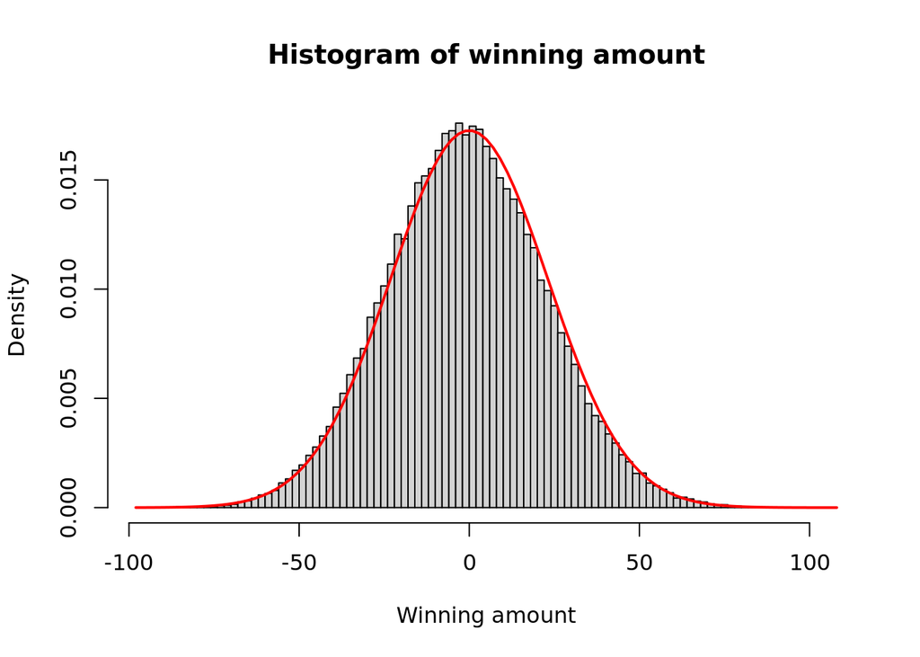

```r
# Histogram of winning amount with normal distribution
hist(sim_result, breaks = 100, freq = FALSE, main = "Histogram of winning amount", xlab = "Winning amount")
# Add a normal curve
curve(dnorm(x, mean = mean(sim_result), sd = sd(sim_result)), col = "red", lwd = 2, add = TRUE)
```

According to the simulation above, the winning amount roughly follows a normal distribution with zero mean, and the average winning amount is -0.02452, which is close to 0. Therefore, I think this is a fair game.

## Problem 2 - Linear Regression

Download the cars data set available at https://corgis-edu.github.io/corgis/csv/cars/. The goal is to examine the relationship between horsepower and highway gas mileage.

```r
# Load the data
cars <- read.csv('./cars.csv')
summary(cars)
```

```
 Dimensions.Height Dimensions.Length Dimensions.Width
 Min.   :  1.0     Min.   :  2.0     Min.   :  1
 1st Qu.:104.0     1st Qu.: 60.0     1st Qu.: 62
 Median :152.0     Median :128.0     Median :158
 Mean   :145.6     Mean   :127.8     Mean   :144
 3rd Qu.:193.0     3rd Qu.:198.0     3rd Qu.:219
 Max.   :255.0     Max.   :255.0     Max.   :254
 Engine.Information.Driveline Engine.Information.Engine.Type
 Length:5076                  Length:5076
 Class :character             Class :character
 Mode  :character             Mode  :character



 Engine.Information.Hybrid Engine.Information.Number.of.Forward.Gears
 Length:5076               Min.   :4.000
 Class :character          1st Qu.:5.000
 Mode  :character          Median :6.000
                           Mean   :5.519
                           3rd Qu.:6.000
                           Max.   :8.000
 Engine.Information.Transmission Fuel.Information.City.mpg
 Length:5076                     Min.   : 8.00
 Class :character                1st Qu.:14.00
 Mode  :character                Median :17.00
                                 Mean   :17.28
                                 3rd Qu.:20.00
                                 Max.   :38.00
 Fuel.Information.Fuel.Type Fuel.Information.Highway.mpg
 Length:5076                Min.   : 11.00
 Class :character           1st Qu.: 20.00
 Mode  :character           Median : 24.00
                            Mean   : 24.13
                            3rd Qu.: 28.00
                            Max.   :223.00
 Identification.Classification Identification.ID  Identification.Make
 Length:5076                   Length:5076        Length:5076
 Class :character              Class :character   Class :character
 Mode  :character              Mode  :character   Mode  :character

```

[output cut: 8 more lines]

```
                           Max.   :2012
 Engine.Information.Engine.Statistics.Horsepower
 Min.   :100.0
 1st Qu.:190.0
 Median :266.0
 Mean   :270.5
 3rd Qu.:317.0
 Max.   :638.0
 Engine.Information.Engine.Statistics.Torque
 Min.   : 98.0
 1st Qu.:187.0
 Median :260.0
 Mean   :272.7
 3rd Qu.:335.0
 Max.   :774.0
```

**a. The names of the variables in this data are way too long. Rename the columns of the data to more reasonable lengths.**

```r
colnames(cars) <- c('height', 'length', 'width', 'driveline', 'engine_type', 'hybrid', 'num_fwd_gears', 'transmission', 'city_mpg', 'fuel_type', 'highway_mpg', 'classification', 'id', 'make', 'model_year', 'year', 'horsepower', 'torque')
summary(cars)
```

```
     height          length          width      driveline
 Min.   :  1.0   Min.   :  2.0   Min.   :  1   Length:5076
 1st Qu.:104.0   1st Qu.: 60.0   1st Qu.: 62   Class :character
 Median :152.0   Median :128.0   Median :158   Mode  :character
 Mean   :145.6   Mean   :127.8   Mean   :144
 3rd Qu.:193.0   3rd Qu.:198.0   3rd Qu.:219
 Max.   :255.0   Max.   :255.0   Max.   :254
 engine_type           hybrid          num_fwd_gears   transmission
 Length:5076        Length:5076        Min.   :4.000   Length:5076
 Class :character   Class :character   1st Qu.:5.000   Class :character
 Mode  :character   Mode  :character   Median :6.000   Mode  :character
                                       Mean   :5.519
                                       3rd Qu.:6.000
                                       Max.   :8.000
    city_mpg      fuel_type          highway_mpg     classification
 Min.   : 8.00   Length:5076        Min.   : 11.00   Length:5076
 1st Qu.:14.00   Class :character   1st Qu.: 20.00   Class :character
 Median :17.00   Mode  :character   Median : 24.00   Mode  :character
 Mean   :17.28                      Mean   : 24.13
 3rd Qu.:20.00                      3rd Qu.: 28.00
 Max.   :38.00                      Max.   :223.00
      id                make            model_year             year
 Length:5076        Length:5076        Length:5076        Min.   :2009
 Class :character   Class :character   Class :character   1st Qu.:2010
 Mode  :character   Mode  :character   Mode  :character   Median :2011
                                                          Mean   :2011
                                                          3rd Qu.:2011
                                                          Max.   :2012
   horsepower        torque
 Min.   :100.0   Min.   : 98.0
 1st Qu.:190.0   1st Qu.:187.0
 Median :266.0   Median :260.0
 Mean   :270.5   Mean   :272.7
 3rd Qu.:317.0   3rd Qu.:335.0
 Max.   :638.0   Max.   :774.0
```

**b. Restrict the data to cars whose Fuel Type is “Gasoline”.**

```r
cars <- cars[cars$fuel_type == 'Gasoline', ]
```

**c. Fit a linear regression model predicting MPG on the highway. The predictor of interest is horsepower. Control for:**

- **The torque of the engine**
- **All three dimensions of the car**
- **The year the car was released, as a categorical variable**

**Briefly discuss the estimated relationship between horsepower and highway MPG. Be precise about the interpretation of the estimated coefficient.**

```r
# Fit a linear regression model
model_lr <- lm(highway_mpg ~ horsepower + torque + height + length + width + factor(year), data = cars)
summary(model_lr)
```

```
Call:
lm(formula = highway_mpg ~ horsepower + torque + height + length +
    width + factor(year), data = cars)

Residuals:
    Min      1Q  Median      3Q     Max
-10.824  -2.550  -0.452   2.372 202.639

Coefficients:
                   Estimate Std. Error t value Pr(>|t|)
(Intercept)      32.2926630  0.7225982  44.690  < 2e-16 ***
horsepower        0.0163556  0.0022772   7.182 7.96e-13 ***
torque           -0.0507425  0.0022030 -23.034  < 2e-16 ***
height            0.0099079  0.0011267   8.794  < 2e-16 ***
length            0.0017290  0.0008836   1.957   0.0504 .
width            -0.0003343  0.0009045  -0.370   0.7117
factor(year)2010 -0.4539681  0.6768246  -0.671   0.5024
factor(year)2011  0.1711016  0.6757043   0.253   0.8001
factor(year)2012  1.3029279  0.6810076   1.913   0.0558 .
---
Signif. codes:  0 '***' 0.001 '**' 0.01 '*' 0.05 '.' 0.1 ' ' 1

Residual standard error: 4.602 on 4582 degrees of freedom
Multiple R-squared:  0.4192,    Adjusted R-squared:  0.4182
F-statistic: 413.3 on 8 and 4582 DF,  p-value: < 2.2e-16
```

According to the summary above, highway MPG is positively correlated with horsepowe, with an estimated coefficient `0.0163556`. If other variable remain unchanged, highway MPG will increase by `0.0163556` for each unit increase in horsepower. Moreover, since the p-value is close to 0, the statistical inference is significant.

**d. It seems reasonable that there may be an interaction between horsepower and torque. Refit the model (with `lm()`) and generate an interaction plot, showing how the relationship between horsepower and MPG changes as torque changes. Choose reasonable values of horsepower, and show lines for three different reasonable values of torque.**

**(Hint: If you choose to use the interactions package for this, look at the `at =` argument to help with how year comes into play - choose a reasonable single value for year.)**

```r
# Refit the model
model_rf <- lm(highway_mpg ~ horsepower * torque + height + length + width + factor(year), data = cars)
summary(model_rf)
```

```
Call:
lm(formula = highway_mpg ~ horsepower * torque + height + length +
    width + factor(year), data = cars)

Residuals:
    Min      1Q  Median      3Q     Max
-11.109  -2.313  -0.258   2.062 203.540

Coefficients:
                    Estimate Std. Error t value Pr(>|t|)
(Intercept)        4.219e+01  7.930e-01  53.199  < 2e-16 ***
horsepower        -1.666e-02  2.539e-03  -6.563 5.84e-11 ***
torque            -8.606e-02  2.533e-03 -33.972  < 2e-16 ***
height             6.560e-03  1.070e-03   6.133 9.32e-10 ***
length             1.777e-03  8.318e-04   2.136   0.0327 *
width             -1.169e-03  8.521e-04  -1.372   0.1700
factor(year)2010  -5.628e-01  6.372e-01  -0.883   0.3771
factor(year)2011   7.254e-02  6.361e-01   0.114   0.9092
factor(year)2012   1.197e+00  6.411e-01   1.867   0.0619 .
horsepower:torque  1.124e-04  4.628e-06  24.276  < 2e-16 ***
---
Signif. codes:  0 '***' 0.001 '**' 0.01 '*' 0.05 '.' 0.1 ' ' 1

Residual standard error: 4.333 on 4581 degrees of freedom
Multiple R-squared:  0.4854,    Adjusted R-squared:  0.4844
F-statistic: 480.1 on 9 and 4581 DF,  p-value: < 2.2e-16
```

```
Using data cars from global environment. This could cause incorrect results
if cars has been altered since the model was fit. You can manually provide
the data to the "data =" argument.
```

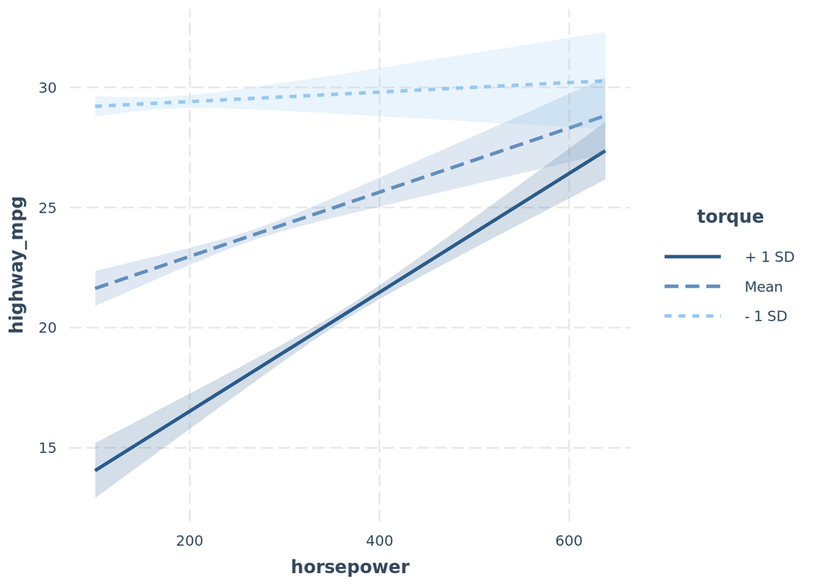

```r
library(interactions)
interact_plot(model_rf, pred = horsepower, modx = torque, interval = TRUE, xlab = "Horsepower", ylab = "Highway MPG", legend_title = "Torque", at = list(year = 2011))
```

**e. Calculate $\hat{\beta}$ from d. manually (without using `lm`) by first creating a proper design matrix, then using matrix algebra to estimate $\beta$. Confirm that you get the same result as `lm` did prior.**

```r
matrix_x <- model.matrix(highway_mpg ~ horsepower + torque + height + length + width + factor(year), data = cars)

beta <- solve(t(matrix_x) %*% matrix_x) %*% t(matrix_x) %*% cars$highway_mpg
beta
```

```
                          [,1]
(Intercept)      32.2926630057
horsepower        0.0163556341
torque           -0.0507424622
height            0.0099078942
length            0.0017289759
width            -0.0003343217
factor(year)2010 -0.4539681241
factor(year)2011  0.1711016371
factor(year)2012  1.3029279007
```

```r
summary(model_lr)
```

```
Call:
lm(formula = highway_mpg ~ horsepower + torque + height + length +
    width + factor(year), data = cars)

Residuals:
    Min      1Q  Median      3Q     Max
-10.824  -2.550  -0.452   2.372 202.639

Coefficients:
                   Estimate Std. Error t value Pr(>|t|)
(Intercept)      32.2926630  0.7225982  44.690  < 2e-16 ***
horsepower        0.0163556  0.0022772   7.182 7.96e-13 ***
torque           -0.0507425  0.0022030 -23.034  < 2e-16 ***
height            0.0099079  0.0011267   8.794  < 2e-16 ***
length            0.0017290  0.0008836   1.957   0.0504 .
width            -0.0003343  0.0009045  -0.370   0.7117
factor(year)2010 -0.4539681  0.6768246  -0.671   0.5024
factor(year)2011  0.1711016  0.6757043   0.253   0.8001
factor(year)2012  1.3029279  0.6810076   1.913   0.0558 .
---
Signif. codes:  0 '***' 0.001 '**' 0.01 '*' 0.05 '.' 0.1 ' ' 1

Residual standard error: 4.602 on 4582 degrees of freedom
Multiple R-squared:  0.4192,    Adjusted R-squared:  0.4182
F-statistic: 413.3 on 8 and 4582 DF,  p-value: < 2.2e-16
```

According to the calculation above, I get the same result by manually calculating as `lm` did prior.

## Problem 3 - Stata

Repeat problem 2 parts a. through d. in Stata.

**Important:** Repeating part e. (manually estimating $\hat{\beta}$) in Stata is optional . You can choose to repeat e. for minor extra credit.

Note: Quarto and Stata don’t play together well, especially if you’re working on Stata remotely. For this problem, and this problem only, you can write a .Do file to answer this question, then include its input and output directly into your submission, by copying the Stata output window and including a non-evaluated chunk.

```stata
// Load the data
. import delimited cars.csv, clear
(encoding automatically selected: ISO-8859-1)
(18 vars, 5,076 obs)

.
. describe

Contains data
 Observations:         5,076
    Variables:            18
--------------------------------------------------------------------------------
Variable      Storage   Display    Value
    name         type    format    label      Variable label
--------------------------------------------------------------------------------
dimensionshei~t int     %8.0g                 Dimensions.Height
dimensionslen~h int     %8.0g                 Dimensions.Length
dimensionswidth int     %8.0g                 Dimensions.Width
engineinform~ne str17   %17s                  Engine Information.Driveline
engineinform~pe str60   %60s                  Engine Information.Engine Type
engineinform~id str4    %9s                   Engine Information.Hybrid
engineinform~rd byte    %8.0g                 Engine Information.Number of
                                                Forward Gears
engineinforma~n str30   %30s                  Engine Information.Transmission
fuelinfor~tympg byte    %8.0g                 Fuel Information.City mpg
fuelinformati~e str22   %22s                  Fuel Information.Fuel Type
fuelinfor~aympg int     %8.0g                 Fuel Information.Highway mpg
identificatio~n str22   %22s                  Identification.Classification
identificatio~d str67   %67s                  Identification.ID
identificatio~e str18   %18s                  Identification.Make
identific~lyear str48   %48s                  Identification.Model Year
identific~nyear int     %8.0g                 Identification.Year
engineinforma~c int     %8.0g                 Engine Information.Engine
                                                Statistics.Horsepower
v18             int     %8.0g                 Engine Information.Engine
                                                Statistics.Torque
--------------------------------------------------------------------------------
Sorted by:
     Note: Dataset has changed since last saved.

.
```

**a. The names of the variables in this data are way too long. Rename the columns of the data to more reasonable lengths.**

```stata
. rename dimensionsheight height

.
. rename dimensionslength length

.
. rename dimensionswidth width

.
. rename engineinformationdriveline driveline

.
. rename engineinformationenginetype engine_type

.
. rename engineinformationhybrid hybrid

.
. rename engineinformationnumberofforward num_fwd_gears

.
. rename engineinformationtransmission transmission

.
. rename fuelinformationcitympg city_mpg

.
. rename fuelinformationfueltype fuel_type

.
. rename fuelinformationhighwaympg highway_mpg

.
. rename identificationclassification classification

.
. rename identificationid id

.
. rename identificationmake make

.
. rename identificationmodelyear model_year

.
. rename identificationyear year

.
. rename engineinformationenginestatistic horsepower

.
. rename v18 torque
```

**b. Restrict the data to cars whose Fuel Type is “Gasoline”.**

```stata
// Restrict the data to cars whose Fuel Type is "Gasoline"
. keep if fuel_type == "Gasoline"
(485 observations deleted)
```

**c. Fit a linear regression model predicting MPG on the highway. The predictor of interest is horsepower. Control for:**

- **The torque of the engine**
- **All three dimensions of the car**
- **The year the car was released, as a categorical variable**

**Briefly discuss the estimated relationship between horsepower and highway MPG. Be precise about the interpretation of the estimated coefficient.**

```stata
// Fit a linear regression model
. reg highway_mpg horsepower torque height length width i.year

      Source |       SS           df       MS      Number of obs   =     4,591
-------------+----------------------------------   F(8, 4582)      =    413.35
       Model |  70043.6695         8  8755.45869   Prob > F        =    0.0000
    Residual |   97055.298     4,582  21.1818634   R-squared       =    0.4192
-------------+----------------------------------   Adj R-squared   =    0.4182
       Total |  167098.968     4,590  36.4050038   Root MSE        =    4.6024

------------------------------------------------------------------------------
 highway_mpg | Coefficient  Std. err.      t    P>|t|     [95% conf. interval]
-------------+----------------------------------------------------------------
  horsepower |   .0163556   .0022772     7.18   0.000     .0118913      .02082
      torque |  -.0507425    .002203   -23.03   0.000    -.0550614   -.0464236
      height |   .0099079   .0011267     8.79   0.000      .007699    .0121168
      length |    .001729   .0008836     1.96   0.050    -3.36e-06    .0034613
       width |  -.0003343   .0009045    -0.37   0.712    -.0021075    .0014388
             |
        year |
       2010  |  -.4539681   .6768246    -0.67   0.502     -1.78087    .8729342
       2011  |   .1711016   .6757043     0.25   0.800    -1.153604    1.495808
       2012  |   1.302928   .6810076     1.91   0.056    -.0321751    2.638031
             |
       _cons |   32.29266   .7225982    44.69   0.000     30.87602     33.7093
------------------------------------------------------------------------------
```

**d. It seems reasonable that there may be an interaction between horsepower and torque. Refit the model (with `lm()`) and generate an interaction plot, showing how the relationship between horsepower and MPG changes as torque changes. Choose reasonable values of horsepower, and show lines for three different reasonable values of torque.**

```stata
// Refit the model
. reg highway_mpg c.horsepower##c.torque height length width i.year

      Source |       SS           df       MS      Number of obs   =     4,591
-------------+----------------------------------   F(9, 4581)      =    480.07
       Model |  81105.8715         9  9011.76351   Prob > F        =    0.0000
    Residual |   85993.096     4,581  18.7716865   R-squared       =    0.4854
-------------+----------------------------------   Adj R-squared   =    0.4844
       Total |  167098.968     4,590  36.4050038   Root MSE        =    4.3326

-------------------------------------------------------------------------------
  highway_mpg | Coefficient  Std. err.      t    P>|t|     [95% conf. interval]
--------------+----------------------------------------------------------------
   horsepower |  -.0166633   .0025388    -6.56   0.000    -.0216406    -.011686
       torque |  -.0860593   .0025333   -33.97   0.000    -.0910257   -.0810928
              |
 c.horsepower#|
     c.torque |   .0001124   4.63e-06    24.28   0.000     .0001033    .0001214
              |
       height |   .0065604   .0010696     6.13   0.000     .0044634    .0086573
       length |   .0017767   .0008318     2.14   0.033     .0001459    .0034075
        width |  -.0011694   .0008521    -1.37   0.170      -.00284    .0005011
              |
         year |
        2010  |  -.5627858   .6371716    -0.88   0.377    -1.811949    .6863777
        2011  |   .0725356   .6361142     0.11   0.909    -1.174555    1.319626
        2012  |   1.197033   .6411085     1.87   0.062    -.0598488    2.453915
              |
        _cons |   42.18795   .7930274    53.20   0.000     40.63323    43.74266
-------------------------------------------------------------------------------

// Interaction plot
. margins, at(horsepower=(100(35)638) year=(2011) torque=(187 260 335))

Predictive margins                                       Number of obs = 4,591
Model VCE: OLS

Expression: Linear prediction, predict()
1._at:  horsepower =  100
        torque     =  187
        year       = 2011
2._at:  horsepower =  100
        torque     =  260
        year       = 2011
3._at:  horsepower =  100
        torque     =  335
        year       = 2011
4._at:  horsepower =  135
        torque     =  187
        year       = 2011
5._at:  horsepower =  135
        torque     =  260
        year       = 2011
6._at:  horsepower =  135
        torque     =  335
        year       = 2011
7._at:  horsepower =  170
        torque     =  187
        year       = 2011
8._at:  horsepower =  170
        torque     =  260
        year       = 2011
9._at:  horsepower =  170
        torque     =  335
        year       = 2011
10._at: horsepower =  205
        torque     =  187
        year       = 2011
11._at: horsepower =  205
        torque     =  260
        year       = 2011
12._at: horsepower =  205
        torque     =  335
        year       = 2011
13._at: horsepower =  240
        torque     =  187
        year       = 2011
14._at: horsepower =  240
        torque     =  260
        year       = 2011
15._at: horsepower =  240
        torque     =  335
        year       = 2011
16._at: horsepower =  275
        torque     =  187
        year       = 2011
17._at: horsepower =  275
        torque     =  260
        year       = 2011
18._at: horsepower =  275
        torque     =  335
        year       = 2011
19._at: horsepower =  310
        torque     =  187
        year       = 2011
20._at: horsepower =  310
        torque     =  260
        year       = 2011
21._at: horsepower =  310
        torque     =  335
        year       = 2011
22._at: horsepower =  345
        torque     =  187
        year       = 2011
23._at: horsepower =  345
        torque     =  260
        year       = 2011
24._at: horsepower =  345
        torque     =  335
        year       = 2011
25._at: horsepower =  380
        torque     =  187
        year       = 2011
26._at: horsepower =  380
        torque     =  260
        year       = 2011
27._at: horsepower =  380
        torque     =  335
        year       = 2011
28._at: horsepower =  415
        torque     =  187
        year       = 2011
29._at: horsepower =  415
        torque     =  260
        year       = 2011
30._at: horsepower =  415
        torque     =  335
        year       = 2011
31._at: horsepower =  450
        torque     =  187
        year       = 2011
32._at: horsepower =  450
        torque     =  260
        year       = 2011
33._at: horsepower =  450
        torque     =  335
        year       = 2011
34._at: horsepower =  485
        torque     =  187
        year       = 2011
35._at: horsepower =  485
        torque     =  260
        year       = 2011
36._at: horsepower =  485
        torque     =  335
        year       = 2011
37._at: horsepower =  520
        torque     =  187
        year       = 2011
38._at: horsepower =  520
        torque     =  260
        year       = 2011
39._at: horsepower =  520
        torque     =  335
        year       = 2011
40._at: horsepower =  555
        torque     =  187
        year       = 2011
41._at: horsepower =  555
        torque     =  260
        year       = 2011
42._at: horsepower =  555
        torque     =  335
        year       = 2011
43._at: horsepower =  590
        torque     =  187
        year       = 2011
44._at: horsepower =  590
        torque     =  260
        year       = 2011
45._at: horsepower =  590
        torque     =  335
        year       = 2011
46._at: horsepower =  625
        torque     =  187
        year       = 2011
47._at: horsepower =  625
        torque     =  260
        year       = 2011
48._at: horsepower =  625
        torque     =  335
        year       = 2011

------------------------------------------------------------------------------
             |            Delta-method
             |     Margin   std. err.      t    P>|t|     [95% conf. interval]
-------------+----------------------------------------------------------------
         _at |
          1  |   27.63439   .2387161   115.76   0.000      27.1664    28.10239
          2  |   22.17227   .3596594    61.65   0.000     21.46717    22.87738
          3  |    16.5605   .5122209    32.33   0.000      15.5563     17.5647
          4  |   27.78655   .1756984   158.15   0.000      27.4421    28.13101
          5  |    22.6115   .2889889    78.24   0.000     22.04494    23.17806
          6  |   17.29467   .4393044    39.37   0.000     16.43342    18.15592
          7  |   27.93871   .1288915   216.76   0.000     27.68602     28.1914
          8  |   23.05073   .2213446   104.14   0.000     22.61679    23.48467
          9  |   18.02883   .3673612    49.08   0.000     17.30863    18.74904
         10  |   28.09087    .119225   235.61   0.000     27.85713    28.32461
         11  |   23.48996   .1605975   146.27   0.000     23.17511    23.80481
         12  |     18.763   .2970992    63.15   0.000     18.18054    19.34546
         13  |   28.24303   .1538658   183.56   0.000     27.94138    28.54468
         14  |   23.92919   .1179361   202.90   0.000     23.69798     24.1604
         15  |   19.49717   .2300639    84.75   0.000     19.04613     19.9482
         16  |   28.39519   .2121162   133.87   0.000     27.97934    28.81104
         17  |   24.36842   .1155228   210.94   0.000     24.14194     24.5949
         18  |   20.23133   .1701135   118.93   0.000     19.89783    20.56484
         19  |   28.54734   .2795896   102.10   0.000     27.99921    29.09547
         20  |   24.80765   .1552461   159.80   0.000     24.50329    25.11201
         21  |    20.9655   .1276541   164.24   0.000     20.71523    21.21576
         22  |    28.6995   .3510071    81.76   0.000     28.01136    29.38765
         23  |   25.24688    .214887   117.49   0.000      24.8256    25.66816
         24  |   21.69966   .1224757   177.18   0.000     21.45955    21.93977
         25  |   28.85166    .424382    67.99   0.000     28.01967    29.68365
         26  |   25.68611   .2820828    91.06   0.000     25.13309    26.23913
         27  |   22.43383   .1582808   141.73   0.000     22.12352    22.74414
         28  |   29.00382   .4988513    58.14   0.000     28.02583    29.98181
         29  |   26.12534   .3525397    74.11   0.000     25.43419    26.81649
         30  |     23.168   .2155297   107.49   0.000     22.74545    23.59054
         31  |   29.15598   .5739893    50.80   0.000     28.03068    30.28127
         32  |   26.56457   .4246375    62.56   0.000     25.73207    27.39706
         33  |   23.90216   .2814269    84.93   0.000     23.35043    24.45389
         34  |   29.30814    .649564    45.12   0.000     28.03468    30.58159
         35  |    27.0038   .4976636    54.26   0.000     26.02814    27.97946
         36  |   24.63633   .3511366    70.16   0.000     23.94793    25.32472
         37  |   29.46029   .7254388    40.61   0.000     28.03808     30.8825
         38  |   27.44303    .571262    48.04   0.000     26.32308    28.56298
         39  |   25.37049   .4227771    60.01   0.000     24.54165    26.19934
         40  |   29.61245   .8015286    36.94   0.000     28.04107    31.18383
         41  |   27.88226    .645237    43.21   0.000     26.61728    29.14723
         42  |   26.10466   .4955116    52.68   0.000     25.13322     27.0761
         43  |   29.76461   .8777774    33.91   0.000     28.04374    31.48548
         44  |   28.32149   .7194724    39.36   0.000     26.91097      29.732
         45  |   26.83882   .5689208    47.17   0.000     25.72347    27.95418
         46  |   29.91677   .9541472    31.35   0.000     28.04618    31.78736
         47  |   28.76072   .7938951    36.23   0.000      27.2043    30.31713
         48  |   27.57299   .6427735    42.90   0.000     26.31285    28.83314
------------------------------------------------------------------------------

.
. marginsplot, title("Interaction Plot between Horsepower and Torque") xtitle("H
> orsepower") ytitle("Highway MPG")
```

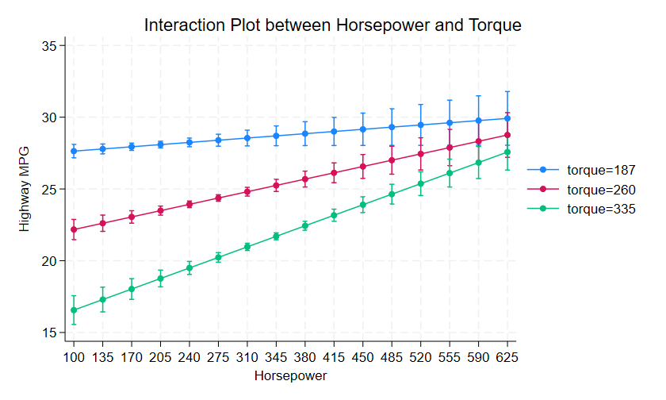